# Legalization and Crime Rates - A Panel Analysis

Shreyas Meher

4/29/2021

## **Introduction**

Here, the variable selected was when the First offense of “low-level” marijuana possession was decriminalized. This variable is a dummy variable, with 0 = no legalization & 1 = first low-level offence decriminalized. In numerous similar studies done, authors look at the difference between legislation-effective and legislation-passed dates, finding no difference between the two and so the normal dummy method is used in this analysis. Sociodemographic variables were used in the model and analysis to control for time-varying effects and influences. These variables are similar to ones used in other research in this domain area, and were all obtained from the IPPSR data set.

### Setting up the Data

```r
test<-read.csv("pdata.csv")

# Loading up required packages

library(VIM)
library(plm)
test$vcrimerate=as.numeric(test$vcrimerate)
test1<-kNN(test)

#Cleaning up extra variables

test1<-subset(test1,select=year:rape)
test1<-pdata.frame(test1,index=c("stateno","year"))
test1$year=as.integer(test1$year)
```

#### Data Imputation

Data was imputed using the kNN package and then the average of the 5 imputations were taken in the final clean dataset with a balanced panel, which will be used further on.

```r
summary(test1)
```

```
##       year         stateno       state              poptotal
##  Min.   : 1.0   1      : 18   Length:918         Min.   :  492924
##  1st Qu.: 5.0   2      : 18   Class :character   1st Qu.: 1726395
##  Median : 9.5   3      : 18   Mode  :character   Median : 4246510
##  Mean   : 9.5   4      : 18                      Mean   : 5909327
##  3rd Qu.:14.0   5      : 18                      3rd Qu.: 6662912
##  Max.   :18.0   6      : 18                      Max.   :39536653
##                 (Other):810
##    popfemale           popmale            cmpdecr          rincarc
##  Min.   :  245408   Min.   :  248374   Min.   :0.0000   Min.   :127.0
##  1st Qu.:  482955   1st Qu.:  484485   1st Qu.:0.0000   1st Qu.:300.5
##  Median : 1800000   Median : 1700000   Median :0.0000   Median :381.0
##  Mean   : 2783772   Mean   : 2702659   Mean   :0.2712   Mean   :396.7
##  3rd Qu.: 3200000   3rd Qu.: 3100000   3rd Qu.:1.0000   3rd Qu.:473.0
##  Max.   :19000000   Max.   :19000000   Max.   :1.0000   Max.   :881.0
##
##    murderrate     propcrimerate    vcrimerate       pc_inc_ann
##  Min.   : 0.800   Min.   :1524   Min.   :  78.2   Min.   : 2.596
##  1st Qu.: 2.900   1st Qu.:2551   1st Qu.: 265.2   1st Qu.: 4.135
##  Median : 5.150   Median :3213   Median : 348.6   Median : 4.931
##  Mean   : 6.367   Mean   :3344   Mean   : 394.1   Mean   : 5.154
##  3rd Qu.: 7.300   3rd Qu.:4079   3rd Qu.: 489.1   3rd Qu.: 5.615
##  Max.   :46.400   Max.   :6409   Max.   :1637.9   Max.   :23.540
##
##    pop18to24           unemp            pov          pop25to44
##  Min.   :  49928   Min.   : 2.20   Min.   : 4.50   Min.   :  130031
##  1st Qu.: 168113   1st Qu.: 4.30   1st Qu.:10.10   1st Qu.:  438939
##  Median : 407748   Median : 5.30   Median :12.20   Median : 1200000
##  Mean   : 587889   Mean   : 5.73   Mean   :12.69   Mean   : 1675065
##  3rd Qu.: 644616   3rd Qu.: 6.70   3rd Qu.:14.90   3rd Qu.: 1800000
##  Max.   :3900000   Max.   :13.70   Max.   :23.10   Max.   :11000000
##
##       rape
##  Min.   : 9.70
##  1st Qu.:25.70
##  Median :31.45
##  Mean   :32.78
##  3rd Qu.:38.80
##  Max.   :93.30
##
```

```r
names(test1)
```

```
##  [1] "year"          "stateno"       "state"         "poptotal"
##  [5] "popfemale"     "popmale"       "cmpdecr"       "rincarc"
##  [9] "murderrate"    "propcrimerate" "vcrimerate"    "pc_inc_ann"
## [13] "pop18to24"     "unemp"         "pov"           "pop25to44"
## [17] "rape"
```

#### Heterogeneity of the Data

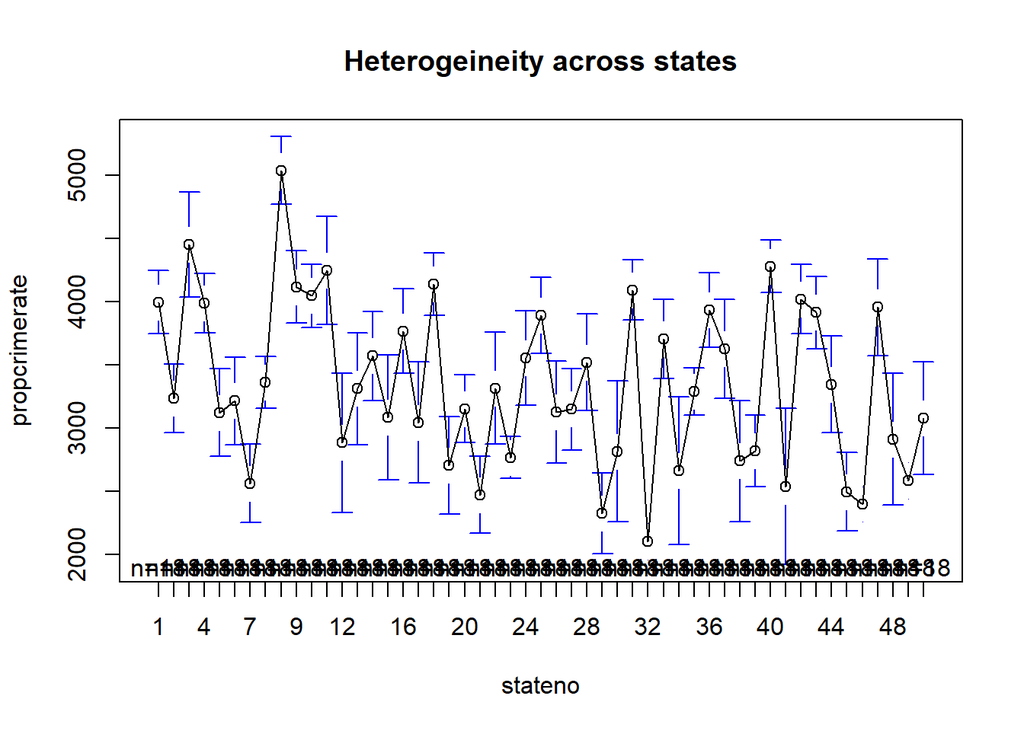

```r
library(gplots)
plotmeans(propcrimerate~stateno, main="Heterogeineity across states",data=test1)
```

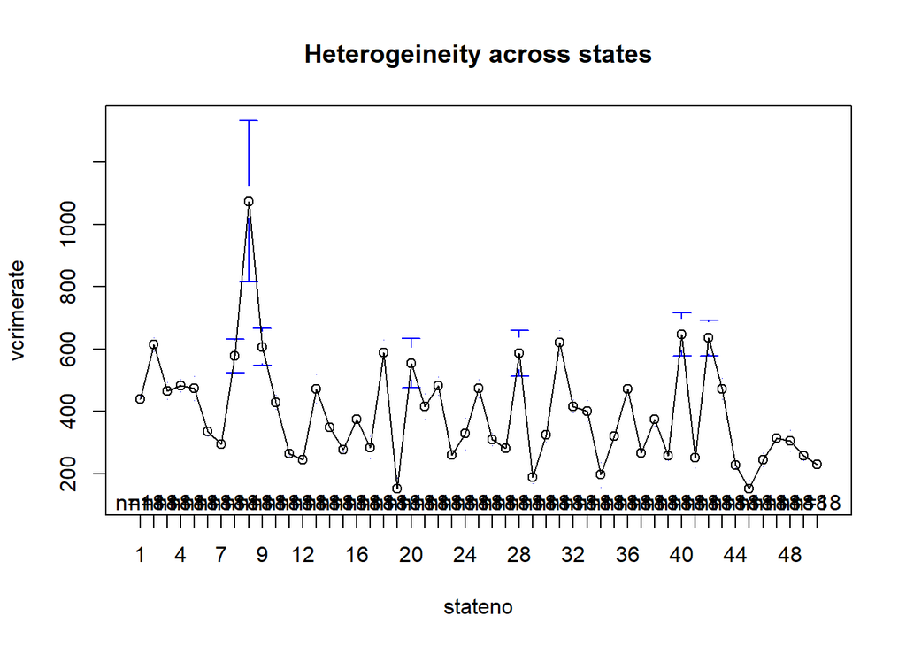

```r
plotmeans(vcrimerate~stateno, main="Heterogeineity across states",data=test1)
```

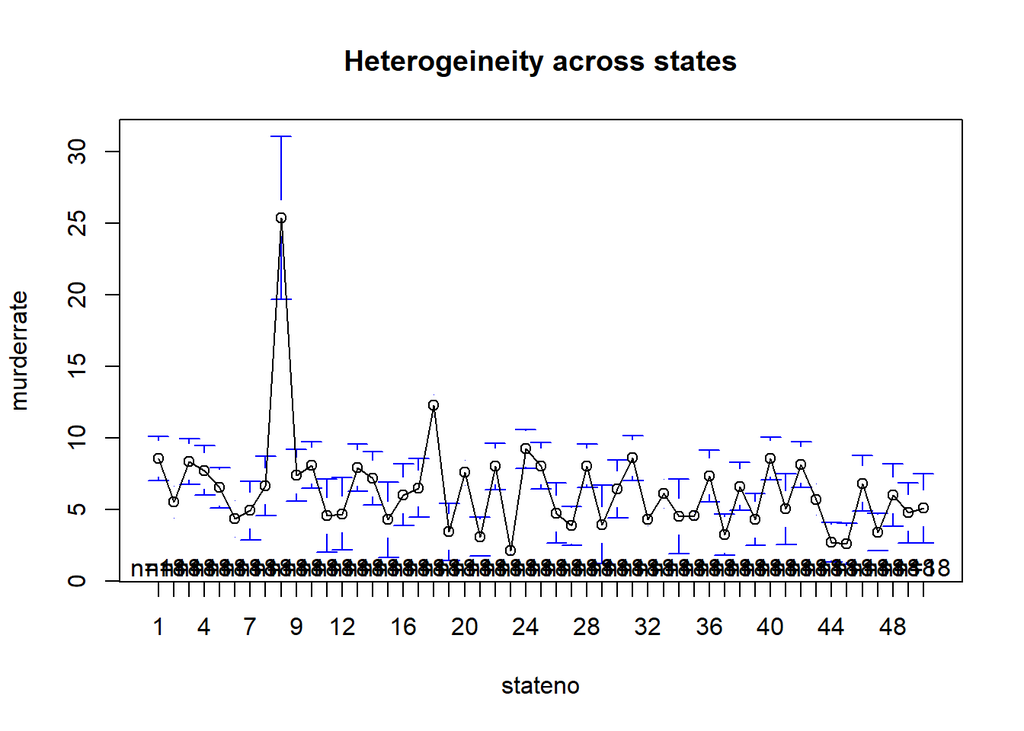

```r
plotmeans(murderrate~stateno, main="Heterogeineity across states",data=test1)
```

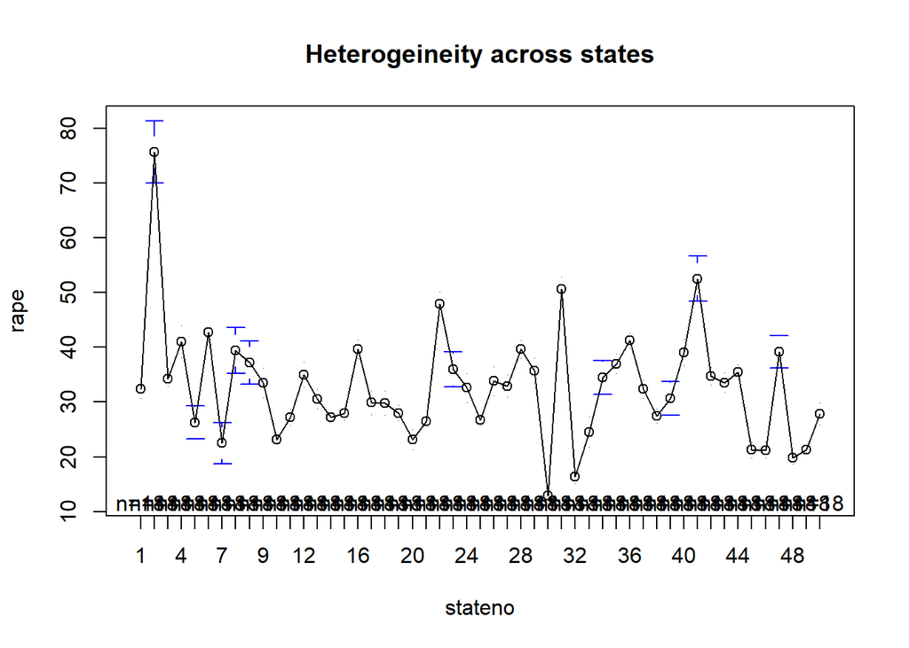

```r
plotmeans(rape~stateno, main="Heterogeineity across states",data=test1)
```

## Model Development

### Transformation of Data

The data is skewed, as we can glean from the density plots in this section. As the dependent variables are rates per 100000 residents of the state, this is understandable. To convert these variables, log transformations are used to resolve them to the normal distribution.

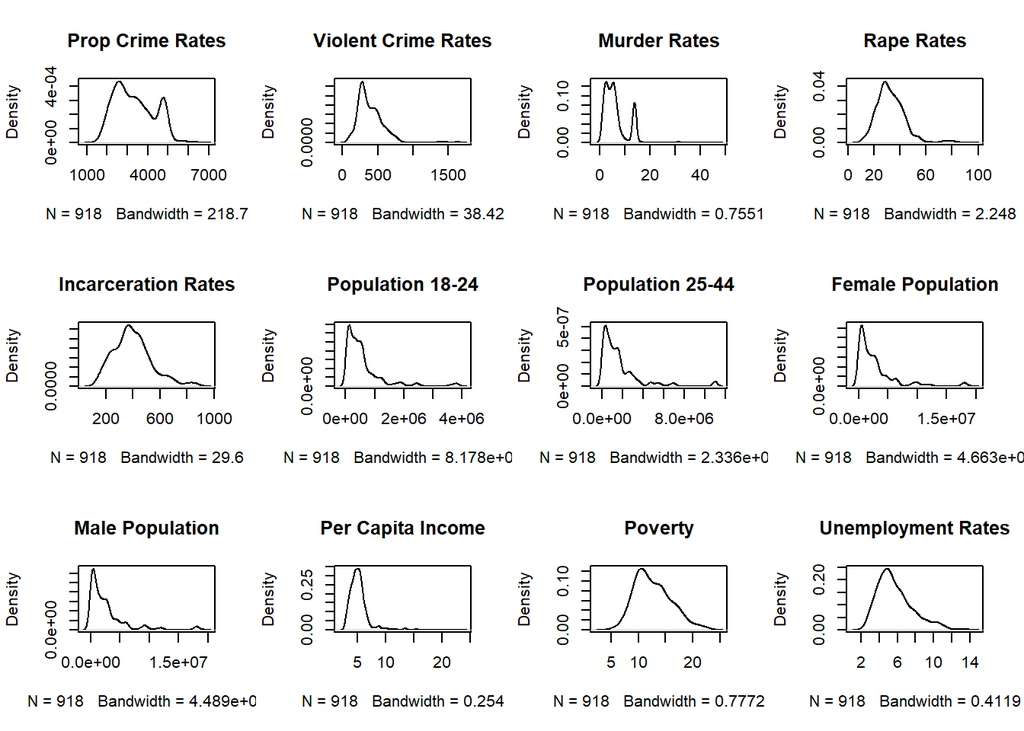

```r
attach(test1)
par(mfrow=c(3,4))
plot(density(propcrimerate),main="Prop Crime Rates")
plot(density(vcrimerate),main="Violent Crime Rates")
plot(density(murderrate),main="Murder Rates")
plot(density(rape,na.rm=TRUE),main="Rape Rates")
plot(density(rincarc),main="Incarceration Rates")
plot(density(pop18to24),main="Population 18-24")
plot(density(pop25to44,na.rm=TRUE), main="Population 25-44")
plot(density(popfemale),main="Female Population")
plot(density(popmale),main="Male Population")
plot(density(pc_inc_ann),main="Per Capita Income")
plot(density(pov),main="Poverty")
plot(density(unemp),main="Unemployment Rates")
```

And after the transformation, we can see that the data approximately follows the normal distribution, which is desirable. The transformed variables will be used for modeling for this paper.

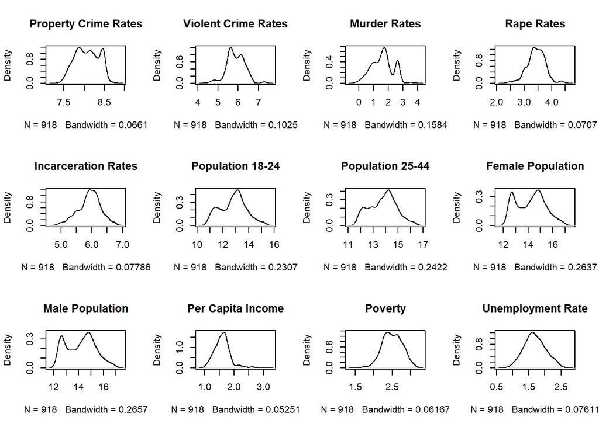

```r
par(mfrow=c(3,4))

plot(density(log(propcrimerate)),main="Property Crime Rates")
plot(density(log(vcrimerate)),main="Violent Crime Rates")
plot(density(log(murderrate)),main="Murder Rates")
plot(density(log(rape),na.rm=TRUE),main="Rape Rates")
plot(density(log(rincarc)),main="Incarceration Rates")
plot(density(log(pop18to24)),main="Population 18-24")
plot(density(log(pop25to44),na.rm=TRUE),main="Population 25-44")
plot(density(log(popfemale)),main="Female Population")
plot(density(log(popmale)),main="Male Population")
plot(density(log(pc_inc_ann)),main="Per Capita Income")
plot(density(log(pov)),main="Poverty")
plot(density(log(unemp)),main="Unemployment Rate")
```

### Variable Selection

```r
#granger causality test

library(lmtest)

grangertest(rincarc~propcrimerate,data=test1)
```

```
## Granger causality test
##
## Model 1: rincarc ~ Lags(rincarc, 1:1) + Lags(propcrimerate, 1:1)
## Model 2: rincarc ~ Lags(rincarc, 1:1)
##   Res.Df Df      F Pr(>F)
## 1    914
## 2    915 -1 0.0024 0.9608
```

```r
grangertest(rincarc~rape,data=test1)
```

```
## Granger causality test
##
## Model 1: rincarc ~ Lags(rincarc, 1:1) + Lags(rape, 1:1)
## Model 2: rincarc ~ Lags(rincarc, 1:1)
##   Res.Df Df      F  Pr(>F)
## 1    914
## 2    915 -1 2.7754 0.09606 .
## ---
## Signif. codes:  0 '***' 0.001 '**' 0.01 '*' 0.05 '.' 0.1 ' ' 1
```

```r
grangertest(rincarc~murderrate,data=test1)
```

```
## Granger causality test
##
## Model 1: rincarc ~ Lags(rincarc, 1:1) + Lags(murderrate, 1:1)
## Model 2: rincarc ~ Lags(rincarc, 1:1)
##   Res.Df Df      F Pr(>F)
## 1    914
## 2    915 -1 0.1614 0.6879
```

```r
grangertest(rincarc~vcrimerate,data=test1)
```

```
## Granger causality test
##
## Model 1: rincarc ~ Lags(rincarc, 1:1) + Lags(vcrimerate, 1:1)
## Model 2: rincarc ~ Lags(rincarc, 1:1)
##   Res.Df Df      F Pr(>F)
## 1    914
## 2    915 -1 2.3102 0.1289
```

## Setting up the Regression Model

### Panel Data Regression models

Panel data econometrics is a continuously developing field. The increasing availability of data observed on cross-sections of units (like households, firms, countries etc.) and over time has given rise to a number of estimation approaches exploiting this double dimensionality to cope with some of the typical problems associated with economic data, first of all that of unobserved heterogeneity.

Timewise observation of data from different observational units has long been common in other fields of statistics (where they are often termed longitudinal data). In the panel data field as well as in others, the econometric approach is nevertheless peculiar with respect to experimental contexts, as it is emphasizing model specification and testing and tackling a number of issues arising from the particular statistical problems associated with economic data.

Time Entity Fixed Effect Model: If a variable is constant across entities but changes over time, the effect is captured by adding time dummy variables and entity fixed effects to the same model as shown below :

$y_{it}=β_1+β_2x_{2it}+...+β_nx_{nit}+γ_1D_1+...+γ_{i−1}D_{i−1}+δ_1T_1+....+δ_{t−1}T_{t−1}+e_{it}$

where,

Note: a dummy variable is always dropped to avoid exact collinearity, so for i variables, i-1 dummy variables will be included in the model

#### Pooled Model

Panel data looks at certain entities, in this case — states, across time for various variables. We cannot use traditional OLS methods to look at the IV-DV relationship. And so in this paper, Panel specific libraries and packages such as ‘plm’, etc. are used to analyse the data that we have. If we use OLS for estimation purposes here, we are assuming that there are no differences/heterogeneity between states, which is not true, as given by the graphs beneath.

The first model that we will try here is a Pooled regression model using the ‘plm’ package. This is basically a simple OLS model where all data points (years) are pooled into one data set and then treated as separate observations. This can be done via the simple ‘lm’ function as well.

```r
#Pooled Regression

library(stargazer)

olsreg<-plm(log(propcrimerate)~cmpdecr+log(pop18to24)+log(pc_inc_ann)+log(unemp)+log(pov)+log(pop25to44),data=test1, index = c("stateno","year"),model = "pooling")

stargazer(olsreg,type = "text",title = "Regression - Pooled Regression")
```

```
##
## Regression - Pooled Regression
## ===========================================
##                     Dependent variable:
##                 ---------------------------
##                     log(propcrimerate)
## -------------------------------------------
## cmpdecr                  -0.068***
##                           (0.020)
##
## log(pop18to24)           -0.034***
##                           (0.009)
##
## log(pc_inc_ann)          -0.127***
##                           (0.035)
##
## log(unemp)               -0.207***
##                           (0.032)
##
## log(pov)                 0.468***
##                           (0.039)
##
## log(pop25to44)            -0.001
##                           (0.010)
##
## Constant                 7.918***
##                           (0.199)
##
## -------------------------------------------
## Observations                918
## R2                         0.188
## Adjusted R2                0.182
## F Statistic       35.067*** (df = 6; 911)
## ===========================================
## Note:           *p<0.1; **p<0.05; ***p<0.01
```

#### Fixed Effects Regression Model

Moving to a fixed effects model, we compare the OLS with the Fixed Effects model. In a fixed effects model, each state is allowed its own intercept.

```r
library(plm)

fixed1<-plm(log(propcrimerate)~cmpdecr+log(pop18to24)+log(pc_inc_ann)+log(unemp)+log(pov)+log(pop25to44)+log(poptotal)+log(popfemale)+log(popmale),index=c("stateno","year"),model="within",effect="individual",data=test1)

fixed2<-plm(log(propcrimerate)~cmpdecr+log(pop18to24)+log(pc_inc_ann)+log(unemp)+log(pov),index=c("stateno","year"),model="within",effect="twoways",data=test1)

stargazer(olsreg,fixed1,fixed2,type = "text",
          title = "Regression - Comparision of Fixed Effects and Pooled",
          column.labels = c("Pooled OLS","State FE","St Yr FE"))
```

```
##
## Regression - Comparision of Fixed Effects and Pooled
## =======================================================================================
##                                           Dependent variable:
##                 -----------------------------------------------------------------------
##                                           log(propcrimerate)
##                       Pooled OLS               State FE                St Yr FE
##                           (1)                     (2)                     (3)
## ---------------------------------------------------------------------------------------
## cmpdecr                -0.068***               -0.152***               -0.221***
##                         (0.020)                 (0.032)                 (0.028)
##
## log(pop18to24)         -0.034***                 0.023                  -0.025
##                         (0.009)                 (0.028)                 (0.024)
##
## log(pc_inc_ann)        -0.127***               -0.151***                -0.035
##                         (0.035)                 (0.034)                 (0.037)
##
## log(unemp)             -0.207***               -0.238***                 0.042
##                         (0.032)                 (0.030)                 (0.046)
##
## log(pov)               0.468***                0.159***                 0.092*
##                         (0.039)                 (0.059)                 (0.055)
##
## log(pop25to44)          -0.001                  -0.027
##                         (0.010)                 (0.026)
##
## log(poptotal)                                   -0.044
##                                                 (0.032)
##
## log(popfemale)                                 1.000***
##                                                 (0.248)
##
## log(popmale)                                   -1.034***
##                                                 (0.241)
##
## Constant               7.918***
##                         (0.199)
##
## ---------------------------------------------------------------------------------------
## Observations              918                     918                     918
## R2                       0.188                   0.240                   0.077
## Adjusted R2              0.182                   0.187                  -0.001
## F Statistic     35.067*** (df = 6; 911) 30.049*** (df = 9; 858) 14.145*** (df = 5; 845)
## =======================================================================================
## Note:                                                       *p<0.1; **p<0.05; ***p<0.01
```

```r
#Testing for Serial Correlation

pbgtest(fixed1)
```

```
##
##  Breusch-Godfrey/Wooldridge test for serial correlation in panel models
##
## data:  log(propcrimerate) ~ cmpdecr + log(pop18to24) + log(pc_inc_ann) +     log(unemp) + log(pov) + log(pop25to44) + log(poptotal) +     log(popfemale) + log(popmale)
## chisq = 319.53, df = 18, p-value < 2.2e-16
## alternative hypothesis: serial correlation in idiosyncratic errors
```

```r
#Testing for Heteroskedasticity

bptest(log(propcrimerate)~cmpdecr+log(pop18to24)+log(pc_inc_ann)+log(unemp)+log(pov)+log(pop25to44),data=test1, studentize=F)
```

```
##
##  Breusch-Pagan test
##
## data:  log(propcrimerate) ~ cmpdecr + log(pop18to24) + log(pc_inc_ann) +     log(unemp) + log(pov) + log(pop25to44)
## BP = 79.519, df = 6, p-value = 4.492e-15
```

```r
#Heteroskedastic Consistent Coefficients

coeftest(fixed1,vcovHC(fixed1,method='arellano'))
```

```
##
## t test of coefficients:
##
##                  Estimate Std. Error t value  Pr(>|t|)
## cmpdecr         -0.151926   0.037594 -4.0412 5.795e-05 ***
## log(pop18to24)   0.023099   0.035039  0.6593   0.50991
## log(pc_inc_ann) -0.151008   0.062208 -2.4275   0.01541 *
## log(unemp)      -0.238456   0.032475 -7.3428 4.863e-13 ***
## log(pov)         0.159260   0.080781  1.9715   0.04899 *
## log(pop25to44)  -0.027389   0.032754 -0.8362   0.40327
## log(poptotal)   -0.043640   0.023153 -1.8848   0.05979 .
## log(popfemale)   1.000479   0.529341  1.8900   0.05909 .
## log(popmale)    -1.033692   0.511504 -2.0209   0.04360 *
## ---
## Signif. codes:  0 '***' 0.001 '**' 0.01 '*' 0.05 '.' 0.1 ' ' 1
```

```r
#Separate Fixed Effects

fixef(fixed1)
```

```
##      1      2      3      4      5      6      7      8    8.5      9     10
## 9.7125 9.7488 9.8397 9.5660 9.8792 9.6857 9.4102 9.4714 9.7636 9.8120 9.7829
##     11     12     13     14     15     16     17     18     19     20     21
## 9.6982 9.2174 9.6327 9.6351 9.3773 9.5872 9.3869 9.7333 9.3206 9.5436 9.3313
##     22     23     24     25     26     27     28     29     30     31     32
## 9.6403 9.5809 9.6305 9.7298 9.3243 9.4731 9.7514 9.0403 9.4641 9.6064 9.3532
##     33     34     35     36     37     38     39     40     41     42     43
## 9.8592 8.9915 9.7631 9.6201 9.7774 9.4330 9.2966 9.8075 8.9117 9.6527 9.8255
##     44     45     46     47     48     49     50
## 9.5343 9.0697 9.2104 9.8644 9.2471 9.3963 9.3036
```

#### Random Effects Model

Following up with the Random effects model, we define further models of our analysis.

```r
random1<-plm(log(propcrimerate)~cmpdecr+log(pop18to24)+log(pc_inc_ann)+log(unemp)+log(pov)+log(pop25to44)+log(poptotal)+log(popfemale)+log(popmale),index=c("stateno","year"),
            model="random",data=test1)


random2<-plm(log(propcrimerate)~cmpdecr+log(pop18to24)+lag(log(pc_inc_ann))+lag(log(unemp))+log(pov),index=c("stateno","year"),
             model="random",data=test1)



random3<-plm(log(propcrimerate)~cmpdecr+log(pop18to24)+log(pc_inc_ann)+log(unemp)+log(pov)+log(pop25to44),data=test1,
             effect = "twoways",model="random",random.method="amemiya")


stargazer(random1,random2,random3,type = "text",title = "Regression - Random Effects Models")
```

```
##
## Regression - Random Effects Models
## ===================================================
##                           Dependent variable:
##                      ------------------------------
##                            log(propcrimerate)
##                         (1)        (2)       (3)
## ---------------------------------------------------
## cmpdecr              -0.123***  -0.133*** -0.195***
##                       (0.028)    (0.031)   (0.026)
##
## log(pop18to24)         -0.013    -0.008    -0.024
##                       (0.017)    (0.019)   (0.019)
##
## log(pc_inc_ann)      -0.169***             -0.052
##                       (0.033)              (0.035)
##
## log(unemp)           -0.239***              0.026
##                       (0.030)              (0.043)
##
## lag(log(pc_inc_ann))             -0.045
##                                  (0.035)
##
## lag(log(unemp))                 -0.223***
##                                  (0.033)
##
## log(pov)              0.248***  0.203***  0.149***
##                       (0.053)    (0.060)   (0.051)
##
## log(pop25to44)         0.013              -0.036**
##                       (0.023)              (0.017)
##
## log(poptotal)          0.008
##                       (0.023)
##
## log(popfemale)        0.981***
##                       (0.242)
##
## log(popmale)         -1.019***
##                       (0.235)
##
## Constant              8.531***  8.149***  8.600***
##                       (0.373)    (0.258)   (0.346)
##
## ---------------------------------------------------
## Observations            918        867       918
## R2                     0.216      0.091     0.083
## Adjusted R2            0.209      0.086     0.076
## F Statistic          250.822*** 86.684*** 81.930***
## ===================================================
## Note:                   *p<0.1; **p<0.05; ***p<0.01
```

## Deciding between Fixed effects or Random effects - The Hausman test

```r
phtest(fixed1,random1)
```

```
##
##  Hausman Test
##
## data:  log(propcrimerate) ~ cmpdecr + log(pop18to24) + log(pc_inc_ann) +  ...
## chisq = 20.313, df = 9, p-value = 0.01607
## alternative hypothesis: one model is inconsistent
```

As the result of the Hausman test is significant, and the null hypothesis is that the preferred model is random effects, we can reject the null and thus we will use a fixed effects model as shown above to model the data. There is correlation between the unique errors and the regressors in this data.

## Violent Crime Rate Model

### Model and Test

```r
fixedv<-plm(log(vcrimerate)~cmpdecr+log(pop18to24)+log(pc_inc_ann)+log(unemp)+log(pov)+log(pop25to44)+log(poptotal)+log(popfemale)+log(popmale),index=c("stateno","year"),model="within",data=test1)

#Testing for Serial Correlation

pbgtest(fixedv)
```

```
##
##  Breusch-Godfrey/Wooldridge test for serial correlation in panel models
##
## data:  log(vcrimerate) ~ cmpdecr + log(pop18to24) + log(pc_inc_ann) +     log(unemp) + log(pov) + log(pop25to44) + log(poptotal) +     log(popfemale) + log(popmale)
## chisq = 380.75, df = 18, p-value < 2.2e-16
## alternative hypothesis: serial correlation in idiosyncratic errors
```

```r
#Testing for Heteroskedasticity

bptest(log(vcrimerate)~cmpdecr+log(pop18to24)+log(pc_inc_ann)+log(unemp)+log(pov)+log(poptotal)+log(popfemale)+log(popmale),data=test1, studentize=F)
```

```
##
##  Breusch-Pagan test
##
## data:  log(vcrimerate) ~ cmpdecr + log(pop18to24) + log(pc_inc_ann) +     log(unemp) + log(pov) + log(poptotal) + log(popfemale) +     log(popmale)
## BP = 276.6, df = 8, p-value < 2.2e-16
```

#### Heteroskedastic and Autoregressive addressed estimates

As R does not have a direct translation to STATA’s ‘xtreg’ command, the package panelAR will be used with a ‘pcse’ panelCorrMethod, giving us a panel weighted least squares estimator after the two-step Prais-Winsten estimator.

```r
library(panelAR)

ARV <- panelAR(formula = log(vcrimerate)~cmpdecr+log(pop18to24)+log(pc_inc_ann)+log(unemp)+log(pov)+log(pop25to44)+log(poptotal)+log(popfemale)+log(popmale),
          data = test1,
          panelVar  = 'stateno',
          timeVar   = 'year',
          autoCorr  = 'ar1',
          rho.na    = TRUE,
          bound.rho = TRUE,
          panelCorrMethod ='pcse')

summary(ARV)
```

```
##
## Panel Regression with AR(1) Prais-Winsten correction and panel-corrected standard errors
##
## Balanced Panel Design:
##  Total obs.:       918 Avg obs. per panel 18
##  Number of panels: 51  Max obs. per panel 18
##  Number of times:  18  Min obs. per panel 18
##
## Coefficients:
##                 Estimate Std. Error t value Pr(>|t|)
## (Intercept)      4.03511    0.52735   7.652 5.06e-14 ***
## cmpdecr         -0.02369    0.03269  -0.725  0.46871
## log(pop18to24)   0.01054    0.01785   0.591  0.55477
## log(pc_inc_ann)  0.07741    0.05034   1.538  0.12443
## log(unemp)      -0.07044    0.04386  -1.606  0.10859
## log(pov)         0.17851    0.04930   3.621  0.00031 ***
## log(pop25to44)   0.01910    0.01996   0.957  0.33896
## log(poptotal)    0.04532    0.02194   2.066  0.03914 *
## log(popfemale)   0.14946    0.22317   0.670  0.50320
## log(popmale)    -0.12754    0.21768  -0.586  0.55808
## ---
## Signif. codes:  0 '***' 0.001 '**' 0.01 '*' 0.05 '.' 0.1 ' ' 1
##
## R-squared: 0.9296
## Wald statistic: 24.1645, Pr(>Chisq(9)): 0.004
```

#### Model Summary

The legalization law variable did not have a statistical effect on the violent crime rate of the time period looked at in this panel. A 1% increase in poverty rate, which was significant, led to a 0.17% increase in the crime rate. The total population variable was also significant, with a positive effect of 0.04%.

#### Year Dummy Model

Here, we can see the trend of the statistical significance for the Violent Crime Rate model through the years of the data. The model is not significant for any years.

```r
fixed3<-plm(log(vcrimerate)~cmpdecr+log(pop18to24)+log(pc_inc_ann)+log(unemp)+log(pov)+log(poptotal)+log(popfemale)+log(popmale)+factor(year),index=c("stateno","year"),
            model="within",data=test1)

coeftest(fixed3,vcovHC)
```

```
##
## t test of coefficients:
##
##                   Estimate Std. Error t value Pr(>|t|)
## cmpdecr         -0.0862549  0.0743510 -1.1601 0.246335
## log(pop18to24)  -0.0137366  0.0532845 -0.2578 0.796627
## log(pc_inc_ann)  0.2827105  0.2062365  1.3708 0.170800
## log(unemp)      -0.2621792  0.0871517 -3.0083 0.002705 **
## log(pov)         0.1366794  0.0957573  1.4274 0.153849
## log(poptotal)    0.0033709  0.0214573  0.1571 0.875203
## log(popfemale)   0.6063568  0.5041854  1.2026 0.229451
## log(popmale)    -0.5229052  0.4965891 -1.0530 0.292646
## factor(year)2    0.0128261  0.0231446  0.5542 0.579607
## factor(year)3    0.0268176  0.0398003  0.6738 0.500620
## factor(year)4    0.0076739  0.0533289  0.1439 0.885616
## factor(year)5   -0.0189731  0.0622201 -0.3049 0.760491
## factor(year)6    0.0077908  0.0744586  0.1046 0.916692
## factor(year)7   -0.0499798  0.0800151 -0.6246 0.532383
## factor(year)8   -0.0866958  0.0855769 -1.0131 0.311315
## factor(year)9   -0.1084103  0.1032952 -1.0495 0.294240
## factor(year)10  -0.0250986  0.1339739 -0.1873 0.851439
## factor(year)11  -0.0607440  0.1445305 -0.4203 0.674384
## factor(year)12  -0.0923393  0.1470577 -0.6279 0.530232
## factor(year)13  -0.1279410  0.1461412 -0.8755 0.381573
## factor(year)14  -0.1655345  0.1425848 -1.1610 0.245989
## factor(year)15  -0.1685881  0.1338836 -1.2592 0.208302
## factor(year)16  -0.1075839  0.1259433 -0.8542 0.393223
## factor(year)17  -0.0989734  0.1746669 -0.5666 0.571109
## factor(year)18  -0.1652842  0.1826476 -0.9049 0.365759
## ---
## Signif. codes:  0 '***' 0.001 '**' 0.01 '*' 0.05 '.' 0.1 ' ' 1
```

## Property Crime Rate Model

### Model and Test

```r
fixedp<-plm(log(propcrimerate)~cmpdecr+log(pop18to24)+log(pc_inc_ann)+log(unemp)+log(pov)+log(pop25to44)+log(poptotal)+log(popfemale)+log(popmale),index=c("stateno","year"),model="within",data=test1)

#Testing for Serial Correlation

pbgtest(fixedp)
```

```
##
##  Breusch-Godfrey/Wooldridge test for serial correlation in panel models
##
## data:  log(propcrimerate) ~ cmpdecr + log(pop18to24) + log(pc_inc_ann) +     log(unemp) + log(pov) + log(pop25to44) + log(poptotal) +     log(popfemale) + log(popmale)
## chisq = 319.53, df = 18, p-value < 2.2e-16
## alternative hypothesis: serial correlation in idiosyncratic errors
```

```r
#Testing for Heteroskedasticity

bptest(log(propcrimerate)~cmpdecr+log(pop18to24)+log(pc_inc_ann)+log(unemp)+log(pov)+log(poptotal)+log(popfemale)+log(popmale),data=test1, studentize=F)
```

```
##
##  Breusch-Pagan test
##
## data:  log(propcrimerate) ~ cmpdecr + log(pop18to24) + log(pc_inc_ann) +     log(unemp) + log(pov) + log(poptotal) + log(popfemale) +     log(popmale)
## BP = 87.075, df = 8, p-value = 1.822e-15
```

#### Heteroskedastic and Autoregressive addressed estimates

```r
library(panelAR)

ARP <- panelAR(formula = log(propcrimerate)~cmpdecr+log(pop18to24)+log(pc_inc_ann)+log(unemp)+log(pov)+log(pop25to44)+log(poptotal)+log(popfemale)+log(popmale),
          data = test1,
          panelVar  = 'stateno',
          timeVar   = 'year',
          autoCorr  = 'ar1',
          rho.na    = TRUE,
          bound.rho = TRUE,
          panelCorrMethod ='pcse')

summary(ARP)
```

```
##
## Panel Regression with AR(1) Prais-Winsten correction and panel-corrected standard errors
##
## Balanced Panel Design:
##  Total obs.:       918 Avg obs. per panel 18
##  Number of panels: 51  Max obs. per panel 18
##  Number of times:  18  Min obs. per panel 18
##
## Coefficients:
##                  Estimate Std. Error t value Pr(>|t|)
## (Intercept)      8.013924   0.482347  16.614  < 2e-16 ***
## cmpdecr         -0.188284   0.041029  -4.589 5.08e-06 ***
## log(pop18to24)  -0.008375   0.010221  -0.819    0.413
## log(pc_inc_ann) -0.107074   0.081521  -1.313    0.189
## log(unemp)      -0.137164   0.098955  -1.386    0.166
## log(pov)         0.263280   0.056926   4.625 4.29e-06 ***
## log(pop25to44)   0.004627   0.023794   0.194    0.846
## log(poptotal)    0.016739   0.026550   0.630    0.529
## log(popfemale)   0.377268   0.335319   1.125    0.261
## log(popmale)    -0.402038   0.350690  -1.146    0.252
## ---
## Signif. codes:  0 '***' 0.001 '**' 0.01 '*' 0.05 '.' 0.1 ' ' 1
##
## R-squared: 0.9583
## Wald statistic: 91.7993, Pr(>Chisq(9)): 0
```

#### Model Summary

In the case of Property related Crime rates, we can see that the main independent variable - legalization status, is significant unlike in the earlier model. It has a negative relationship. The poverty rate was also significant with a positive coefficient, with 1% increase in poverty rate leading to a 0.26% increase in property crime rate.

#### Year Dummy Model

Here, we can see the trend of the statistical significance for the Property Rate model through the years of the data.

```r
fixed2<-plm(log(propcrimerate)~cmpdecr+log(pop18to24)+log(pc_inc_ann)+log(unemp)+log(pov)+log(poptotal)+log(popfemale)+log(popmale)+factor(year),index=c("stateno","year"),
            model="within",data=test1)

coeftest(fixed2,vcovHC)
```

```
##
## t test of coefficients:
##
##                  Estimate Std. Error t value  Pr(>|t|)
## cmpdecr         -0.228220   0.042440 -5.3775 9.792e-08 ***
## log(pop18to24)  -0.033653   0.024060 -1.3987 0.1622695
## log(pc_inc_ann) -0.028977   0.078330 -0.3699 0.7115206
## log(unemp)       0.034344   0.065749  0.5223 0.6015683
## log(pov)         0.091691   0.059982  1.5286 0.1267293
## log(poptotal)   -0.038655   0.019525 -1.9797 0.0480606 *
## log(popfemale)  -0.196537   0.369729 -0.5316 0.5951641
## log(popmale)     0.221524   0.367348  0.6030 0.5466462
## factor(year)2   -0.014921   0.014360 -1.0391 0.2990683
## factor(year)3   -0.043351   0.026009 -1.6668 0.0959268 .
## factor(year)4   -0.069184   0.031486 -2.1973 0.0282725 *
## factor(year)5   -0.089112   0.031760 -2.8058 0.0051344 **
## factor(year)6   -0.105270   0.033448 -3.1473 0.0017060 **
## factor(year)7   -0.125020   0.031914 -3.9175 9.674e-05 ***
## factor(year)8   -0.144787   0.035565 -4.0711 5.121e-05 ***
## factor(year)9   -0.203595   0.046349 -4.3927 1.262e-05 ***
## factor(year)10  -0.251674   0.069535 -3.6194 0.0003129 ***
## factor(year)11  -0.258408   0.073786 -3.5021 0.0004859 ***
## factor(year)12  -0.251504   0.069331 -3.6276 0.0003033 ***
## factor(year)13  -0.288228   0.065390 -4.4079 1.179e-05 ***
## factor(year)14  -0.340257   0.060405 -5.6329 2.415e-08 ***
## factor(year)15   0.094894   0.071783  1.3220 0.1865396
## factor(year)16   0.039995   0.065992  0.6061 0.5446402
## factor(year)17   0.142991   0.091558  1.5618 0.1187208
## factor(year)18   0.211445   0.086017  2.4582 0.0141655 *
## ---
## Signif. codes:  0 '***' 0.001 '**' 0.01 '*' 0.05 '.' 0.1 ' ' 1
```

## Murder Rate Model

### Model and Test

```r
fixedm<-plm(log(murderrate)~cmpdecr+log(pop18to24)+log(pc_inc_ann)+log(unemp)+log(pov)+log(pop25to44)+log(poptotal)+log(popfemale)+log(popmale),index=c("stateno","year"),model="within",data=test1)

#Testing for Serial Correlation

pbgtest(fixedm)
```

```
##
##  Breusch-Godfrey/Wooldridge test for serial correlation in panel models
##
## data:  log(murderrate) ~ cmpdecr + log(pop18to24) + log(pc_inc_ann) +     log(unemp) + log(pov) + log(pop25to44) + log(poptotal) +     log(popfemale) + log(popmale)
## chisq = 303.66, df = 18, p-value < 2.2e-16
## alternative hypothesis: serial correlation in idiosyncratic errors
```

```r
#Testing for Heteroskedasticity

bptest(log(murderrate)~cmpdecr+log(pop18to24)+log(pc_inc_ann)+log(unemp)+log(pov)+log(pop25to44)+log(poptotal)+log(popfemale)+log(popmale),data=test1, studentize=F)
```

```
##
##  Breusch-Pagan test
##
## data:  log(murderrate) ~ cmpdecr + log(pop18to24) + log(pc_inc_ann) +     log(unemp) + log(pov) + log(pop25to44) + log(poptotal) +     log(popfemale) + log(popmale)
## BP = 164.54, df = 9, p-value < 2.2e-16
```

#### Heteroskedastic and Autoregressive addressed estimates

```r
library(panelAR)

ARM <- panelAR(formula = log(murderrate)~cmpdecr+log(pop18to24)+log(pc_inc_ann)+log(unemp)+log(pov)+log(pop25to44)+log(poptotal)+log(popfemale)+log(popmale),
          data = test1,
          panelVar  = 'stateno',
          timeVar   = 'year',
          autoCorr  = 'ar1',
          rho.na    = TRUE,
          bound.rho = TRUE,
          panelCorrMethod ='pcse')

summary(ARM)
```

```
##
## Panel Regression with AR(1) Prais-Winsten correction and panel-corrected standard errors
##
## Balanced Panel Design:
##  Total obs.:       918 Avg obs. per panel 18
##  Number of panels: 51  Max obs. per panel 18
##  Number of times:  18  Min obs. per panel 18
##
## Coefficients:
##                  Estimate Std. Error t value Pr(>|t|)
## (Intercept)     -1.779548   1.266419  -1.405   0.1603
## cmpdecr         -0.343165   0.081398  -4.216 2.74e-05 ***
## log(pop18to24)   0.003117   0.024403   0.128   0.8984
## log(pc_inc_ann)  0.199854   0.191236   1.045   0.2963
## log(unemp)      -0.249696   0.225702  -1.106   0.2689
## log(pov)         0.739728   0.134169   5.513 4.59e-08 ***
## log(pop25to44)   0.074987   0.064352   1.165   0.2442
## log(poptotal)    0.126550   0.074661   1.695   0.0904 .
## log(popfemale)   1.947408   0.854548   2.279   0.0229 *
## log(popmale)    -2.040117   0.884265  -2.307   0.0213 *
## ---
## Signif. codes:  0 '***' 0.001 '**' 0.01 '*' 0.05 '.' 0.1 ' ' 1
##
## R-squared: 0.2115
## Wald statistic: 133.6769, Pr(>Chisq(9)): 0
```

#### Year Dummy Model

```r
fixed4<-plm(log(murderrate)~cmpdecr+log(pop18to24)+log(pc_inc_ann)+log(unemp)+log(pov)+log(poptotal)+log(popfemale)+log(popmale)+factor(year),index=c("stateno","year"),
            model="within",data=test1)

coeftest(fixed4,vcovHC)
```

```
##
## t test of coefficients:
##
##                   Estimate Std. Error t value  Pr(>|t|)
## cmpdecr         -0.4164444  0.1311863 -3.1745 0.0015558 **
## log(pop18to24)  -0.0645073  0.0945654 -0.6821 0.4953347
## log(pc_inc_ann)  0.3338765  0.2470133  1.3517 0.1768490
## log(unemp)      -0.1676451  0.1362181 -1.2307 0.2187747
## log(pov)         0.1576287  0.1620343  0.9728 0.3309269
## log(poptotal)   -0.0232403  0.0444471 -0.5229 0.6011990
## log(popfemale)   1.1695409  0.9389983  1.2455 0.2132873
## log(popmale)    -1.0330485  0.9257251 -1.1159 0.2647686
## factor(year)2   -0.0036067  0.0427666 -0.0843 0.9328108
## factor(year)3    0.0545796  0.0632032  0.8636 0.3880774
## factor(year)4    0.0422397  0.0784431  0.5385 0.5903909
## factor(year)5    0.0207397  0.0853350  0.2430 0.8080345
## factor(year)6    0.0307636  0.0946814  0.3249 0.7453248
## factor(year)7   -0.0085668  0.1059804 -0.0808 0.9355934
## factor(year)8   -0.0694620  0.1083044 -0.6414 0.5214640
## factor(year)9   -0.1697540  0.1352300 -1.2553 0.2097187
## factor(year)10  -0.1185407  0.1751571 -0.6768 0.4987390
## factor(year)11  -0.0925082  0.2016968 -0.4586 0.6466040
## factor(year)12  -0.0977045  0.1822989 -0.5360 0.5921291
## factor(year)13  -0.1343097  0.1773903 -0.7571 0.4491766
## factor(year)14  -0.1428539  0.1723222 -0.8290 0.4073432
## factor(year)15   0.7737587  0.1960857  3.9460 8.608e-05 ***
## factor(year)16   0.7706155  0.1869802  4.1214 4.139e-05 ***
## factor(year)17   0.9274264  0.2654827  3.4934 0.0005018 ***
## factor(year)18   0.9968249  0.2525230  3.9475 8.558e-05 ***
## ---
## Signif. codes:  0 '***' 0.001 '**' 0.01 '*' 0.05 '.' 0.1 ' ' 1
```

## Rape Rate Model

### Model and Test

```r
fixedr<-plm(log(rape)~cmpdecr+log(pop18to24)+log(pc_inc_ann)+log(unemp)+log(pov)+log(pop25to44)+
                 log(poptotal)+log(popfemale)+log(popmale),index=c("stateno","year"),model="within",data=test1)

#Testing for Serial Correlation

pbgtest(fixedr)
```

```
##
##  Breusch-Godfrey/Wooldridge test for serial correlation in panel models
##
## data:  log(rape) ~ cmpdecr + log(pop18to24) + log(pc_inc_ann) + log(unemp) +     log(pov) + log(pop25to44) + log(poptotal) + log(popfemale) +     log(popmale)
## chisq = 277.75, df = 18, p-value < 2.2e-16
## alternative hypothesis: serial correlation in idiosyncratic errors
```

```r
#Testing for Heteroskedasticity

bptest(log(rape)~cmpdecr+log(pop18to24)+log(pc_inc_ann)+log(unemp)+log(pov)+log(pop25to44)+
                 log(poptotal)+log(popfemale)+log(popmale),data=test1, studentize=F)
```

```
##
##  Breusch-Pagan test
##
## data:  log(rape) ~ cmpdecr + log(pop18to24) + log(pc_inc_ann) + log(unemp) +     log(pov) + log(pop25to44) + log(poptotal) + log(popfemale) +     log(popmale)
## BP = 107.56, df = 9, p-value < 2.2e-16
```

#### Heteroskedastic and Autoregressive addressed estimates

```r
library(panelAR)

ARR <- panelAR(formula = log(rape)~cmpdecr+log(pop18to24)+log(pc_inc_ann)+log(unemp)+log(pov)+log(pop25to44)+
                 log(poptotal)+log(popfemale)+log(popmale),
          data = test1,
          panelVar  = 'stateno',
          timeVar   = 'year',
          autoCorr  = 'ar1',
          rho.na    = TRUE,
          bound.rho = TRUE,
          panelCorrMethod ='pcse')

summary(ARR)
```

```
##
## Panel Regression with AR(1) Prais-Winsten correction and panel-corrected standard errors
##
## Balanced Panel Design:
##  Total obs.:       918 Avg obs. per panel 18
##  Number of panels: 51  Max obs. per panel 18
##  Number of times:  18  Min obs. per panel 18
##
## Coefficients:
##                  Estimate Std. Error t value Pr(>|t|)
## (Intercept)      4.308557   0.364297  11.827  < 2e-16 ***
## cmpdecr          0.016194   0.027768   0.583 0.559920
## log(pop18to24)   0.045732   0.012044   3.797 0.000156 ***
## log(pc_inc_ann) -0.038505   0.040199  -0.958 0.338384
## log(unemp)      -0.035686   0.038207  -0.934 0.350543
## log(pov)        -0.035867   0.037905  -0.946 0.344274
## log(pop25to44)  -0.074650   0.016552  -4.510 7.33e-06 ***
## log(poptotal)    0.005949   0.018887   0.315 0.752864
## log(popfemale)  -0.401231   0.194460  -2.063 0.039367 *
## log(popmale)     0.380716   0.190278   2.001 0.045707 *
## ---
## Signif. codes:  0 '***' 0.001 '**' 0.01 '*' 0.05 '.' 0.1 ' ' 1
##
## R-squared: 0.8737
## Wald statistic: 97, Pr(>Chisq(9)): 0
```

#### Year Dummy Model

Here, we can see the trend of the statistical significance for the Rape Rate model through the years of the data. The data is not significant for most years, and only slightly significant for a few.

```r
fixed5<-plm(log(rape)~cmpdecr+log(pop18to24)+log(pc_inc_ann)+log(unemp)+log(pov)+log(poptotal)+log(popfemale)+log(popmale)+factor(year),index=c("stateno","year"),
            model="within",data=test1)

coeftest(fixed5,vcovHC)
```

```
##
## t test of coefficients:
##
##                   Estimate Std. Error t value Pr(>|t|)
## cmpdecr         -0.0040878  0.0430691 -0.0949 0.924406
## log(pop18to24)   0.0603065  0.0476366  1.2660 0.205874
## log(pc_inc_ann) -0.0067760  0.0492852 -0.1375 0.890680
## log(unemp)      -0.0819706  0.0503903 -1.6267 0.104172
## log(pov)        -0.1881654  0.0692427 -2.7175 0.006713 **
## log(poptotal)    0.0310077  0.0200909  1.5434 0.123117
## log(popfemale)  -0.9230545  0.2882175 -3.2026 0.001413 **
## log(popmale)     0.8985003  0.2811448  3.1959 0.001446 **
## factor(year)2   -0.0148978  0.0181796 -0.8195 0.412744
## factor(year)3    0.0550743  0.0218894  2.5160 0.012054 *
## factor(year)4    0.0481491  0.0264883  1.8178 0.069457 .
## factor(year)5    0.0494611  0.0264333  1.8712 0.061668 .
## factor(year)6    0.0259221  0.0250615  1.0343 0.301274
## factor(year)7    0.0382222  0.0260135  1.4693 0.142119
## factor(year)8   -0.0033520  0.0290173 -0.1155 0.908061
## factor(year)9    0.0151507  0.0393096  0.3854 0.700023
## factor(year)10   0.0239567  0.0522517  0.4585 0.646721
## factor(year)11   0.0192375  0.0543941  0.3537 0.723676
## factor(year)12  -0.0018535  0.0531871 -0.0348 0.972208
## factor(year)13  -0.0026500  0.0541896 -0.0489 0.961009
## factor(year)14  -0.0487934  0.0518394 -0.9412 0.346851
## factor(year)15  -0.0968244  0.0484884 -1.9969 0.046162 *
## factor(year)16  -0.0267842  0.0380949 -0.7031 0.482193
## factor(year)17   0.0083406  0.0508155  0.1641 0.869664
## factor(year)18   0.0198745  0.0480254  0.4138 0.679102
## ---
## Signif. codes:  0 '***' 0.001 '**' 0.01 '*' 0.05 '.' 0.1 ' ' 1
```

#### Model Summary

In the case of Rape Rate, the main independent variable of legalization is not significant and only the sociodemographic control of population between 18 to 24 is significant in this model, with a 1% increase in the population leading to a 0.05% increase in rape rate. The population between 25 to 44 variable was also significant, with a 1% increase leading to a -0.07% decrease in rape rate. The population variables for female and male were also significant, with a negative sign for the female variable and positive for male.

## Analysis of the Results

The results of the four models specified above lead us to believe that legalization does have a small effect, except in the case of Violent Crimes and Rape Crimes. It is understandable that legalization would have led to a decrease in property crime rates, as drug consumption has been linked to small-level crimes across the literature present and focusing on the United States. More analysis will be needed to have a conclusive result. This research paves the way for further inquiry into the effect of consumption of marijuana on crime rates as well, as due to federal restrictions and the Schedule I specification of the drug being a further impediment to scientific research on the substance. The coefficient of the legalization variable in the models tested were not negative for all types of crime rates, but are low enough to suggest that there may be a negative relationship between crime rates and legalization. Future research would include much more localized data, preferably county or even city level data and a comparison between neighboring states with differences in legalization status would lead to even more robust results.

## Conclusion

The data explored was controlled for the various shortcomings related to Panel Data, such as serial correlation and heteroskedasticity. There are significant effects seen for the main independent variable for Property Crime Rates and Murder Rates and not for Violent Crime Rates and Rape Rates. And so we cannot conclusively say that legalization leads to a change in crime rates without further research and adding even more sociodemographic control variables.